# misión-exploración-español

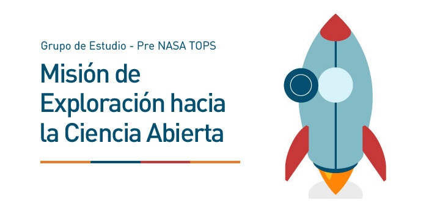

## ¿Quién se registró?

Un total de 94 participantes de 18 paises diferentes se inscribieron para las sesiones.

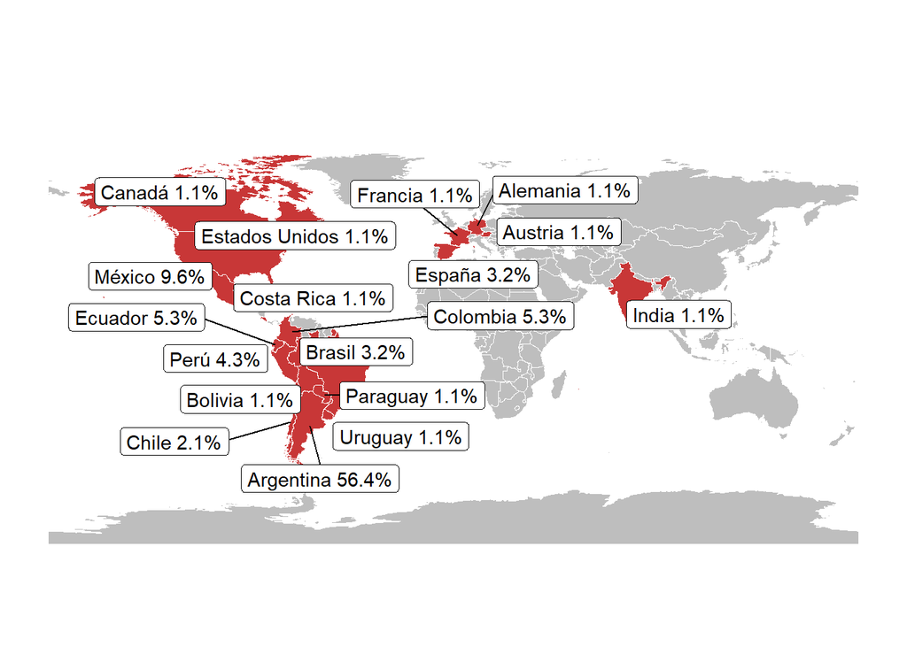

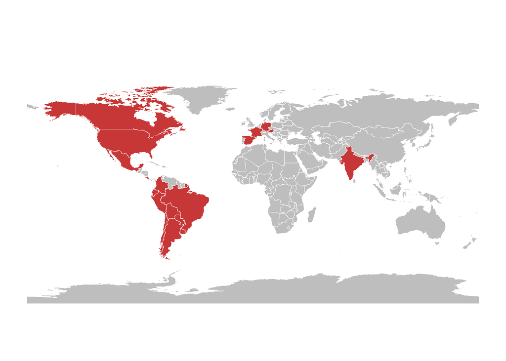

## Comunidad

De los 94 participantes que mostraron interés en el evento, 25 reportaron participar como representantes de una comunidad.

| Comunidades | N | % |
| --- | --- | --- |
| @openlabec, openlab.ec | 1 | 1.1 |
| Abrmios.info | 1 | 1.1 |
| Epidemiología Perú, https://www.facebook.com/profile.php?id=100063770093129 | 1 | 1.1 |
| Fundación Charles Darwin https://www.darwinfoundation.org/es/ | 1 | 1.1 |
| ILDA | 1 | 1.1 |
| MetaDocencia | 8 | 8.5 |
| Nibö, niboe.info | 1 | 1.1 |
| Proyecto CoAct | 1 | 1.1 |
| Python Norte SciPy LA Escuela Bayesiana UNSa | 1 | 1.1 |
| R-Ladies Guayaquil - @RLadiesGye | 1 | 1.1 |
| Revista Propulsión https://ojs.revpropulsion.cl/index.php/revpropulsion/index | 1 | 1.1 |
| SciELO México - https://www.facebook.com/ScieloMexicoOficial/ | 1 | 1.1 |
| Secretaría de Investigación - Facultad de Ciencias Sociales - UNCórdoba https://sociales.unc.edu.ar/ | 1 | 1.1 |
| Sistema de Bibliotecas, Universidad de Guadalajara (https://bibliotecas.udg.mx/) | 1 | 1.1 |
| UNLP | 1 | 1.1 |
| Universidad de costa rica | 1 | 1.1 |
| eScire - www.escire.lat | 1 | 1.1 |
| www.bibliotecarural.com | 1 | 1.1 |

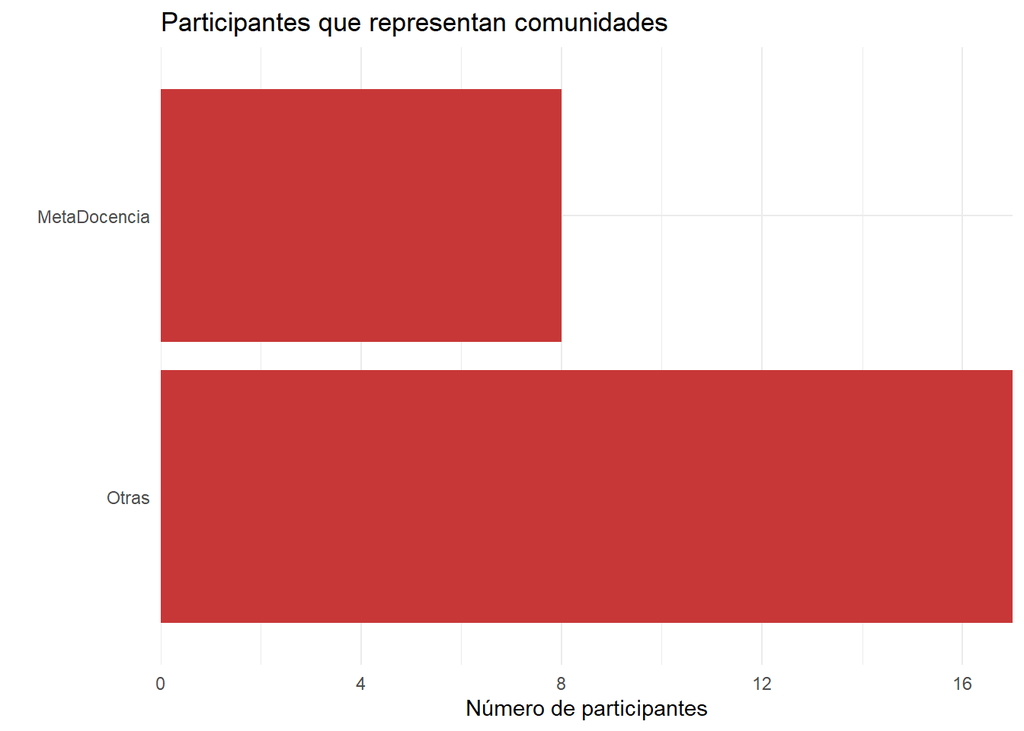

## Requerimientos de accesibilidad

| accesibilidad | N | % |
| --- | --- | --- |
| Compartir grabaciones | 1 | 1.1 |
| Interpretación, traducción o subtítulos en español | 14 | 14.9 |
| Sin requerimientos | 79 | 84.0 |

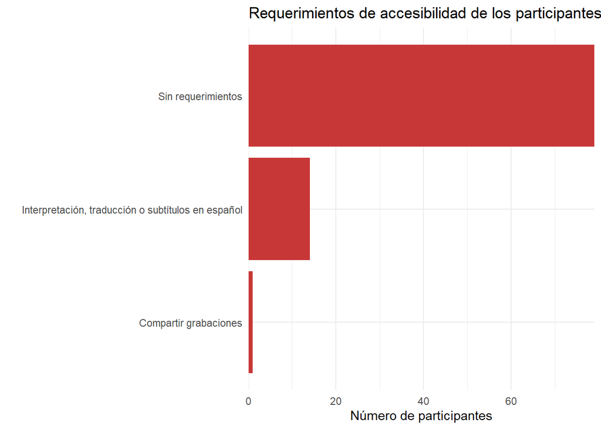

## ¿Cómo se enteraron los participantes de la actividad?

El 50.5% (n = 54) de los participantes conocieron la actividad de las siguientes formas

- Por correo electrónico
- Me invitó una persona conocida

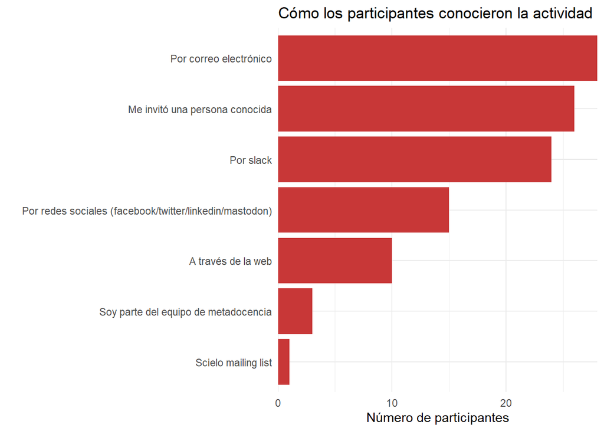

## ¿Por qué los participantes están interesados en esta actividad?

- Ampliar el conocimiento acerca de Ciencia Abierta
- Adquirir herramientas para mi práctica
- Trabajo en Ciencia Abierta y/o se vincula con mi investigación

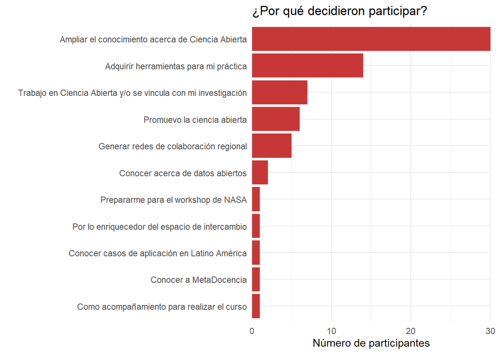

## ¿Cómo fue la participación en zoom?

De los 94 participantes que se inscribieron al curso, 83 (88.3%) asistieron a las reuniones.

| Evento | N | % |
| --- | --- | --- |
| 06-03-2024 | 21 | 22.3 |
| 07-02-2024 | 25 | 26.6 |
| 13-03-2024 | 28 | 29.8 |
| 14-02-2024 | 16 | 17.0 |
| 20-03-2024 | 33 | 35.1 |
| 21-02-2024 | 18 | 19.1 |
| 24-01-2024 | 29 | 30.9 |
| 27-03-2024 | 19 | 20.2 |
| 31-01-2024 | 26 | 27.7 |

La asistencia media por evento fue de 23.9 participantes (DE = 5.7).

| Evento | Asistentes | Permanecieron hasta el final | % |
| --- | --- | --- | --- |
| 06-03-2024 | 21 | 18 | 85.7 |
| 07-02-2024 | 25 | 20 | 80.0 |
| 13-03-2024 | 28 | 22 | 78.6 |
| 14-02-2024 | 16 | 15 | 93.8 |
| 20-03-2024 | 33 | 27 | 81.8 |
| 21-02-2024 | 18 | 15 | 83.3 |
| 24-01-2024 | 29 | 24 | 82.8 |
| 27-03-2024 | 19 | 16 | 84.2 |
| 31-01-2024 | 26 | 20 | 76.9 |

Una media de 83% de los asistentes permanecieron hasta el final de las sesiones. El tiempo medio de asistencia fue de 67.1 minutos, con una desviación estándar de 24.3.

## ¡Nos certificamos!

De los 83 participantes que asisteron a las reuniones de zoom, 21 (25.3%) alcanzaron su certificación de NASA TOPS.

## Devolución de los participantes

### Net Promoter Score

Clasificamos a los participantes en promotores (puntuaciones 9-10), que están muy satisfechos y muy propensos a recomendar la actividad a otros; pasivos o neutrales (puntuaciones 7-8), que están algo satisfechos pero pueden no ser tan entusiastas en sus recomendaciones; y detractores (puntuaciones de 0 a 6), que están insatisfechos y pueden disuadir activamente a otros de participar.

Para calcular el NPS restamos el porcentaje de detractores del porcentaje de promotores. La puntuación puede oscilar entre -100 (si todos los encuestados son detractores) y +100 (si todos los encuestados son promotores).

Al hacerlo, obtuvimos un NPS de 79.2%. Un NPS superior al 20% se considera favorable y superior al 50% excelente.

### Cosas para mantener

Después de cada reunión, pedimos a los participantes que compartieran algo que les gustó del encuentro y que les gustaría conservar. Agrupamos las respuestas en las siguientes categorías:

- **Múltiples perspectivas y discusión** incluye comentarios sobre la interdisciplinariedad, el espacio para compartir experiencias y perspectivas, y lo enriquecedores que pueden ser los diferentes puntos de vista.
- **Formato y presentación** incluye comentarios sobre el formato participativo, cómo se llevaron a cabo las sesiones y los materiales que se compartieron, como diapositivas y documentos compartidos.
- **Comunidad** incluye comentarios que mencionan explícitamente la palabra “comunidad”, pero también aquellos que resaltan la importancia de una experiencia compartida.
- **Contenido** incluye comentarios que se refieren específicamente a la información que se compartió durante la reunión.
- **Contexto latinoamericano** e **Idioma español** incluyen comentarios que mencionan explícitamente estos temas.

La respuesta de un participante puede pertenecer a más de una categoría cuando incluye varios temas.

De las 72 respuestas que obtuvimos, 61.1% (44 participantes) destaco aspectos relacionados con Múltiples perspectivas y discusión; 25% (18 participantes) concentrarse en Formato y presentación; y 12.5% (9 participantes) enfatizaron el Contexto latinoamericano aspecto de la actividad. Estas fueron las categorías más frecuentes.

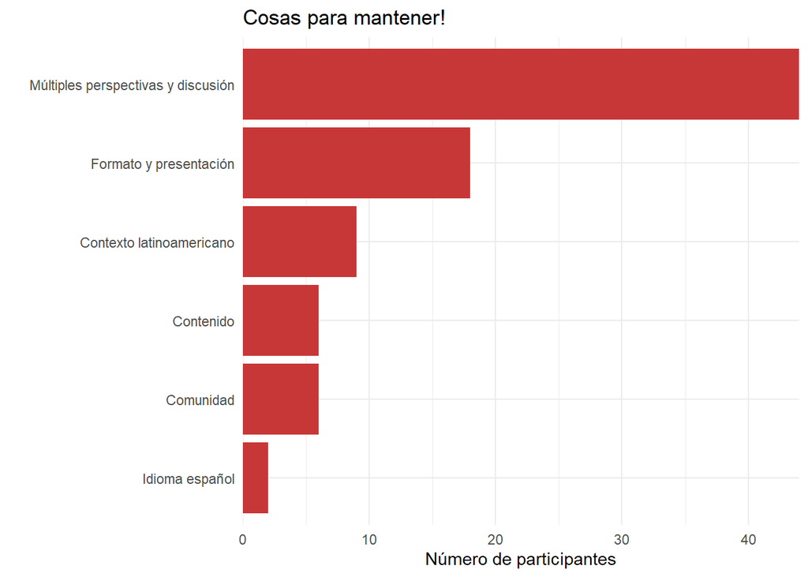

En general, concluimos que los asistentes apreciaron las diversas perspectivas y las interesantes discusiones, lo cual fue posible gracias al formato dinámico que utilizamos. Espacios de intercambio como este fomentan un sentido de comunidad, especialmente cuando contextualizamos el contenido a la región e idioma de los participantes, todo contribuyendo a una experiencia rica y valiosa.

### Cosas para mejorar

Después de cada reunión, pedimos a los participantes que compartieran sugerencias que tuvieran para mejorar los encuentros. Agrupamos las respuestas en las siguientes categorías:

- **Reuniones más largas** incluye sugerencias para ampliar la duración de las reuniones.
- **Organizar interacciones** incluye comentarios sobre cómo participaron los asistentes y cómo esto puede distraer en algunos casos.
- **Traducir el contenido que está en inglés** incluye comentarios respecto al idioma del contenido como barrera.
- **Ampliar la discusión** se refiere a la sugerencia de poner a disposición otros canales de comunicación para discutir estos temas de forma asincrónica, mediante el uso del documento para compartir, y también a la sugerencia de participar en salas de trabajo.
- **Limitar hipertextualidad** se refiere a la cantidad de enlaces y referencias externas en el material.
- **Presentar un mapa del tema**, **Relacionar materiales de lectura con América Latina**, **Crear un repositorio que centralice los primeros pasos**, **Superposición de materiales**, **Puntualidad** y **Ampliar la aplicabilidad en todos los campos** donde se mencione explícitamente.

La respuesta de un participante puede pertenecer a más de una categoría cuando incluye varios temas.

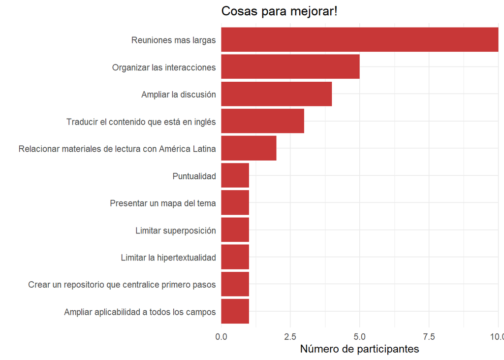

En conjunto, llegamos a la conclusión de que las sugerencias de mejora se centran principalmente en mejorar los elementos interactivos ampliando la duración de las reuniones, ampliando los debates a plataformas adicionales, proporcionando traducciones del contenido en inglés, profundizando en la relevancia de varias disciplinas e integrando materiales de lectura relevantes para el Contexto latinoamericano.

## ¡Se unieron a Slack!

Actualmente, el #nasa-tops canal tiene 58 miembros, 61.7% de el total de participantes que se inscribieron en Misión de Exploración (94), de los cuales 31 (33%) participaron activamente en el canal.